# HST1 normative step length calculations

```r
pacman::p_load(tidyverse, meta)
```

Oberg 1993 Table 8a.

```r
SL.men = tibble(
   sex = "Male",
   age.cat = c('10-14','15-19','20-29','30-39','40-49','50-59','60-69','70-79'),
   age.mid = c(12.5,17.5,25,35,45,55,65,75),
   N = c(12,15,15,15,15,15,15,14),
   mean.cm = c(61.5, 66.0, 61.6, 64.9, 64.7, 63.5, 65.0, 61.5),
   SD.cm = c(3.9, 4.8, 3.5, 4.6, 3.7, 6.0, 3.6, 5.1),
)

SL.women = tibble(
   sex = "Female",
   age.cat = c('10-14','15-19','20-29','30-39','40-49','50-59','60-69','70-79'),
   age.mid = c(12.5,17.5,25,35,45,55,65,75),
   N = c(12,15,15,15,15,15,15,15),
   mean.cm = c(54.2, 59.3, 59.1, 59.7, 57.1, 53.5, 55.3, 54.2),
   SD.cm = c(2.9, 4.3, 6.3, 5.3, 3.7, 2.6, 4.2, 3.7)
)

SL = bind_rows(SL.men, SL.women) %>%
  mutate(CV = SD.cm / mean.cm) %>%
   filter(age.mid > 30)

SL
```

```
## # A tibble: 10 × 7
##    sex    age.cat age.mid     N mean.cm SD.cm     CV
##    <chr>  <chr>     <dbl> <dbl>   <dbl> <dbl>  <dbl>
##  1 Male   30-39        35    15    64.9   4.6 0.0709
##  2 Male   40-49        45    15    64.7   3.7 0.0572
##  3 Male   50-59        55    15    63.5   6   0.0945
##  4 Male   60-69        65    15    65     3.6 0.0554
##  5 Male   70-79        75    14    61.5   5.1 0.0829
##  6 Female 30-39        35    15    59.7   5.3 0.0888
##  7 Female 40-49        45    15    57.1   3.7 0.0648
##  8 Female 50-59        55    15    53.5   2.6 0.0486
##  9 Female 60-69        65    15    55.3   4.2 0.0759
## 10 Female 70-79        75    15    54.2   3.7 0.0683
```

Get regression model to smooth estimates across ages

```r
lm = lm(mean.cm ~ age.mid * sex, data=SL)
summary(lm)
```

```
##
## Call:
## lm(formula = mean.cm ~ age.mid * sex, data = SL)
##
## Residuals:
##    Min     1Q Median     3Q    Max
## -2.460 -0.395 -0.005  0.755  1.730
##
## Coefficients:
##                 Estimate Std. Error t value Pr(>|t|)
## (Intercept)     63.00000    2.64654  23.805 3.61e-07 ***
## age.mid         -0.12800    0.04660  -2.747   0.0334 *
## sexMale          4.49500    3.74277   1.201   0.2750
## age.mid:sexMale  0.06300    0.06591   0.956   0.3760
## ---
## Signif. codes:  0 '***' 0.001 '**' 0.01 '*' 0.05 '.' 0.1 ' ' 1
##
## Residual standard error: 1.474 on 6 degrees of freedom
## Multiple R-squared:  0.9321, Adjusted R-squared:  0.8982
## F-statistic: 27.47 on 3 and 6 DF,  p-value: 0.0006658
```

Or, better yet, using meta-regression

```r
meta = metagen(TE=mean.cm, seTE=SD.cm/sqrt(N), data=SL)
metareg(meta, ~age.mid*sex)
```

```
##
## Mixed-Effects Model (k = 10; tau^2 estimator: REML)
##
## tau^2 (estimated amount of residual heterogeneity):     1.5991 (SE = 1.5720)
## tau (square root of estimated tau^2 value):             1.2645
## I^2 (residual heterogeneity / unaccounted variability): 60.19%
## H^2 (unaccounted variability / sampling variability):   2.51
## R^2 (amount of heterogeneity accounted for):            92.24%
##
## Test for Residual Heterogeneity:
## QE(df = 6) = 16.4347, p-val = 0.0116
##
## Test of Moderators (coefficients 2:4):
## QM(df = 3) = 70.0078, p-val < .0001
##
## Model Results:
##
##                  estimate      se     zval    pval    ci.lb    ci.ub
## intrcpt           62.3704  3.0815  20.2404  <.0001  56.3308  68.4100  ***
## age.mid           -0.1202  0.0536  -2.2443  0.0248  -0.2252  -0.0152    *
## sexMale            4.8810  4.3750   1.1157  0.2646  -3.6939  13.4559
## age.mid:sexMale    0.0621  0.0769   0.8073  0.4195  -0.0886   0.2128
##
## ---
## Signif. codes:  0 '***' 0.001 '**' 0.01 '*' 0.05 '.' 0.1 ' ' 1
```

Equation for normative SL based on age and sex:

$62.3704 - 0.1202*age + 4.8810(if.male) + 0.0621*age (if.male)$

Or, can use separate equations for women/men: Women: 62.3704 - 0.1202*age Men: 67.2514 - 0.0581*age

Plot for mean SL

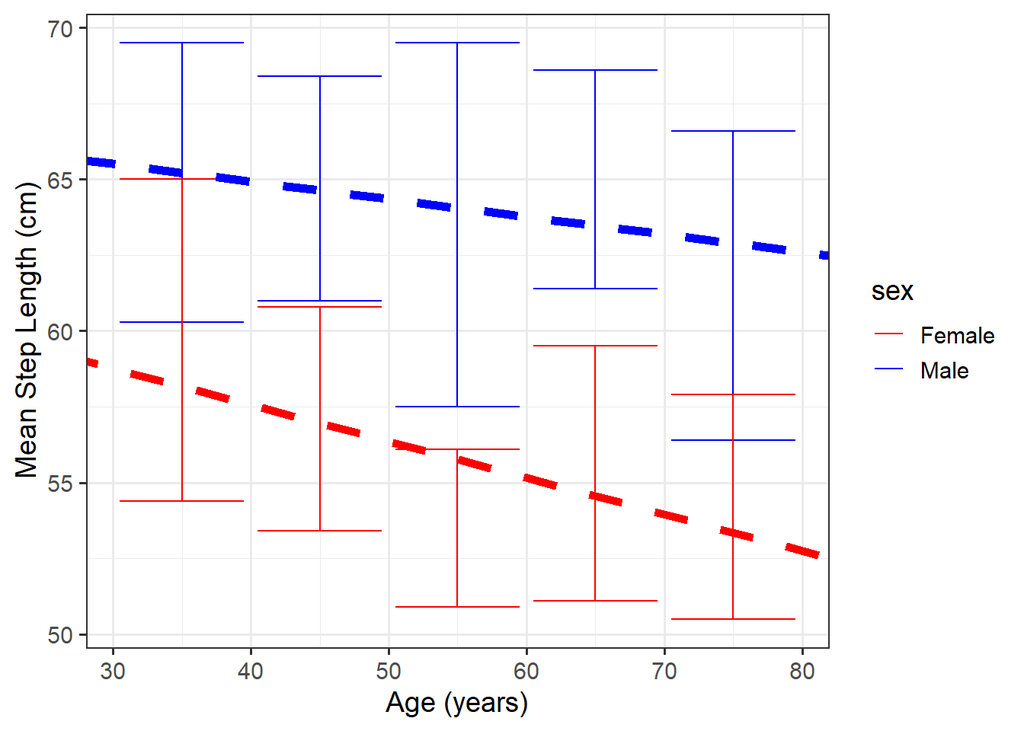

```r
ggplot(data=SL, mapping=aes(x=age.mid, y=mean.cm, ymin=mean.cm-SD.cm, ymax=mean.cm+SD.cm, group=sex, color=sex)) +
   geom_errorbar() +
   scale_color_manual(values=c("red","blue")) +
   geom_abline(intercept=62.3704, slope=-0.1202, col="red", lwd=2, lty=2) +
   geom_abline(intercept=67.2514, slope=-0.0581, col="blue", lwd=2, lty=2) +
   theme_bw(base_size=14) +
   labs(x="Age (years)", y="Mean Step Length (cm)")
```

Meta-analysis for SD (actually for variance)

```r
meta.varSL = metagen(TE=SD.cm^2, seTE=SD.cm^2 * sqrt(2/(N-1)), data=SL)
meta.varSL
```

```
## Number of studies: k = 10
##
##                                          95%-CI    z  p-value
## Common effect model  12.2813 [ 9.0544; 15.5082] 7.46 < 0.0001
## Random effects model 14.5044 [10.0198; 18.9891] 6.34 < 0.0001
##
## Quantifying heterogeneity (with 95%-CIs):
##  tau^2 = 15.7213 [0.0000; >157.2125]; tau = 3.9650 [0.0000; >12.5384]
##  I^2 = 35.0% [0.0%; 69.0%]; H = 1.24 [1.00; 1.80]
##
## Test of heterogeneity:
##      Q d.f. p-value
##  13.86    9  0.1275
##
## Details of meta-analysis methods:
## - Inverse variance method
## - Restricted maximum-likelihood estimator for tau^2
## - Q-Profile method for confidence interval of tau^2 and tau
## - Calculation of I^2 based on Q
```

```r
metareg(meta.varSL, ~ age.mid * sex) # no effect of age or sex
```

```
##
## Mixed-Effects Model (k = 10; tau^2 estimator: REML)
##
## tau^2 (estimated amount of residual heterogeneity):     25.7390 (SE = 36.3821)
## tau (square root of estimated tau^2 value):             5.0734
## I^2 (residual heterogeneity / unaccounted variability): 42.89%
## H^2 (unaccounted variability / sampling variability):   1.75
## R^2 (amount of heterogeneity accounted for):            0.00%
##
## Test for Residual Heterogeneity:
## QE(df = 6) = 10.8663, p-val = 0.0926
##
## Test of Moderators (coefficients 2:4):
## QM(df = 3) = 1.0441, p-val = 0.7906
##
## Model Results:
##
##                  estimate       se     zval    pval     ci.lb    ci.ub
## intrcpt           19.0493  15.9193   1.1966  0.2315  -12.1519  50.2504
## age.mid           -0.1044   0.2727  -0.3829  0.7018   -0.6390   0.4301
## sexMale           -2.6597  22.9303  -0.1160  0.9077  -47.6023  42.2828
## age.mid:sexMale    0.1339   0.4026   0.3325  0.7395   -0.6552   0.9230
##
## ---
## Signif. codes:  0 '***' 0.001 '**' 0.01 '*' 0.05 '.' 0.1 ' ' 1
```

```r
metareg(meta.varSL, ~ mean.cm) # possible higher variability with higher mean values - let's calculate CV instead
```

```
##
## Mixed-Effects Model (k = 10; tau^2 estimator: REML)
##
## tau^2 (estimated amount of residual heterogeneity):     7.2328 (SE = 20.0721)
## tau (square root of estimated tau^2 value):             2.6894
## I^2 (residual heterogeneity / unaccounted variability): 16.53%
## H^2 (unaccounted variability / sampling variability):   1.20
## R^2 (amount of heterogeneity accounted for):            53.99%
##
## Test for Residual Heterogeneity:
## QE(df = 8) = 9.4120, p-val = 0.3087
##
## Test of Moderators (coefficient 2):
## QM(df = 1) = 2.5164, p-val = 0.1127
##
## Model Results:
##
##          estimate       se     zval    pval     ci.lb    ci.ub
## intrcpt  -24.4196  24.1104  -1.0128  0.3111  -71.6752  22.8359
## mean.cm    0.6537   0.4121   1.5863  0.1127   -0.1540   1.4615
##
## ---
## Signif. codes:  0 '***' 0.001 '**' 0.01 '*' 0.05 '.' 0.1 ' ' 1
```

Plot for SD SL

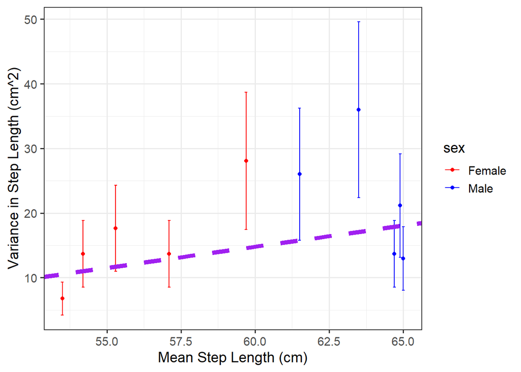

```r
ggplot(data=SL, mapping=aes(x=mean.cm, y=SD.cm^2, col=sex, ymin=SD.cm^2-SD.cm^2 * sqrt(2/(N-1)), ymax=SD.cm^2+SD.cm^2 * sqrt(2/(N-1)))) +
   geom_errorbar() + geom_point() +
   scale_color_manual(values=c("red","blue")) +
   geom_abline(intercept=-24.4196, slope=0.6537, col="purple", lwd=2, lty=2) +
   theme_bw(base_size=14) +
   labs(x="Mean Step Length (cm)", y="Variance in Step Length (cm^2)")
```

```r
meta.CV.SL = metagen(TE=CV, seTE=sqrt( CV^2 / (N-1) * (0.5 + CV^2 ) ), data=SL)
metareg(meta.CV.SL, ~ age.mid * sex) # no effect of age or sex
```

```
##
## Mixed-Effects Model (k = 10; tau^2 estimator: REML)
##
## tau^2 (estimated amount of residual heterogeneity):     0.0001 (SE = 0.0002)
## tau (square root of estimated tau^2 value):             0.0117
## I^2 (residual heterogeneity / unaccounted variability): 45.40%
## H^2 (unaccounted variability / sampling variability):   1.83
## R^2 (amount of heterogeneity accounted for):            0.00%
##
## Test for Residual Heterogeneity:
## QE(df = 6) = 10.9756, p-val = 0.0891
##
## Test of Moderators (coefficients 2:4):
## QM(df = 3) = 0.2401, p-val = 0.9709
##
## Model Results:
##
##                  estimate      se     zval    pval    ci.lb   ci.ub
## intrcpt            0.0781  0.0337   2.3171  0.0205   0.0120  0.1442  *
## age.mid           -0.0002  0.0006  -0.3560  0.7219  -0.0014  0.0009
## sexMale           -0.0181  0.0466  -0.3877  0.6982  -0.1093  0.0732
## age.mid:sexMale    0.0004  0.0008   0.4465  0.6552  -0.0012  0.0020
##
## ---
## Signif. codes:  0 '***' 0.001 '**' 0.01 '*' 0.05 '.' 0.1 ' ' 1
```

```r
meta.CV.SL
```

```
## Number of studies: k = 10
##
##                                       95%-CI     z  p-value
## Common effect model  0.0649 [0.0571; 0.0728] 16.25 < 0.0001
## Random effects model 0.0662 [0.0572; 0.0751] 14.45 < 0.0001
##
## Quantifying heterogeneity (with 95%-CIs):
##  tau^2 < 0.0001 [0.0000; 0.0005]; tau = 0.0066 [0.0000; 0.0228]
##  I^2 = 19.8% [0.0%; 60.3%]; H = 1.12 [1.00; 1.59]
##
## Test of heterogeneity:
##      Q d.f. p-value
##  11.22    9  0.2611
##
## Details of meta-analysis methods:
## - Inverse variance method
## - Restricted maximum-likelihood estimator for tau^2
## - Q-Profile method for confidence interval of tau^2 and tau
## - Calculation of I^2 based on Q
```

Plot for CV SL

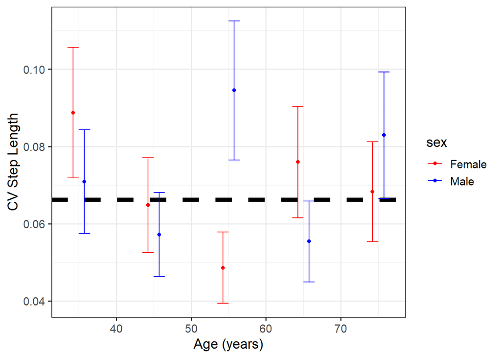

```r
ggplot(data=SL, mapping=aes(x=age.mid, y=CV,
                            ymin=CV - sqrt( CV^2 / (N-1) * (0.5 + CV^2 ) ),
                            ymax=CV + sqrt( CV^2 / (N-1) * (0.5 + CV^2 ) ),
                            group=sex, color=sex)) +
  geom_hline(yintercept=0.0662, lwd=2, lty=2) +
  geom_errorbar(position=position_dodge(width=3), width=3) +
  geom_point(position=position_dodge(width=3)) +
  scale_color_manual(values=c("red","blue")) +
  theme_bw(base_size=14) +
  labs(x="Age (years)", y="CV Step Length")
```

# Use CV to calculate SD

Since between study variability (I2) is lower for CV vs. SD, and SD seems to increase with the mean (not quite significant but under-powered).

CV does not appear to be influenced by age or sex

# Final formulas

Neurotypical step length: Women: 62.3704 - 0.1202*age Men: 67.2514 - 0.0581*age

CV in neurotypical step length = 6.62% SD in neurotypical step length = expected step length x 0.0662

Low step length = lower than the 2.5th percentile of neurotypical step length = lower than mean neurotypical step length - 1.96 SDs